# Mean Variance Portfolio Allocation

Yu-Ting Huang

2022-01-01

# Project Introduction

This project looked into the intuition behind mean-variance portfolio allocation by analysing a set of country-level equity indexes.

# Computing Daily Returns From Price Data

First of all, the original data were cleaned and sorted as data frame. In addition, index prices were converted from local currencies to USD for better manipulation in the following questions.

```r
# load libraries
library(readxl)
library(xts)
library(openxlsx)
library(dplyr)
library(quantmod)
library(zoo)
library(mnormt)
library(moments)
```

## Modifying prices by exchange rates

```r
# original price
price <- read_excel("PS1_data.xls",sheet ="hard_copy", skip = 2)
```

```
* `` -> ...1
* `` -> ...2
* `` -> ...3
* `` -> ...13
* `` -> ...14
* ...
```

```r
price <- price[c(4:12)]

# exchange rate
exchange_rate <- read_excel("PS1_data.xls", sheet ="hard_copy",skip = 2)
```

```
* `` -> ...1
* `` -> ...2
* `` -> ...3
* `` -> ...13
* `` -> ...14
* ...
```

```r
exchange_rate <- exchange_rate[c(14:21)]
exchange_rate <- cbind(price[,1],exchange_rate)

price <- as.data.frame(price)
exchange_rate <- as.data.frame(exchange_rate)
exchange_rate <- setNames(exchange_rate, c("date","TSX","CAC","DAX","Euro50","NIKKEI","FTSE","SP500","IBOVESPA"))
#head(exchange_rate)
#head(price)

# get total date
n = as.numeric(nrow(price))

# convert price to dollar
price $TSX <- price$TSX*exchange_rate$TSX
price $CAC <- price$CAC*exchange_rate$CAC
price $DAX <- price$DAX*exchange_rate$DAX
price $Eurostoxx50 <- price$Eurostoxx50*exchange_rate$Euro50
price $NIKKEI225 <- price$NIKKEI225*exchange_rate$NIKKEI
price $FTSE100 <- price$FTSE100*exchange_rate$FTSE
price $SP500 <- price$SP500*exchange_rate$SP500
price $IBOVESPA<- price$IBOVESPA*exchange_rate$IBOVESPA
# head(price)
```

## Calculating daily returns

Since the stock market do not open on weekends and other holidays, we need to adjust those values by deleting the rows where the returns are 0.

```r
daily_return <- (price[-1,-1]-price[-n,-1])/price[-n,-1]
daily_return <- cbind(price$date[-1],daily_return)
daily_return <- daily_return[!rowSums(daily_return[,-1]) == 0,]
colnames(daily_return)[1]="date"
daily_return$date <- as.Date(daily_return$date, "%Y/%m/%d")
```

```
unknown timezone '%Y/%m/%d'
```

```r
#daily_return <- replace(daily_return, daily_return==0, NA)
#head(daily_return)
```

## Calculating log daily return

As required, daily returns were converted to log returns and below showed daily log returns for each index, using the following formula:
$$log\_return_t = log(\frac{p_t}{p_{t-1}})$$

```r
log_daily_return <- log(price[-1,-1]/price[-n,-1])
log_daily_return <- cbind(price$date[-1],log_daily_return)
log_daily_return <- log_daily_return[!rowSums(log_daily_return[,-1]) == 0,]

colnames(log_daily_return)[1]="date"
log_daily_return$date <- as.Date(log_daily_return$date, "%Y/%m/%d")
```

```
unknown timezone '%Y/%m/%d'
```

```r
#log_daily_return <- replace(log_daily_return, log_daily_return==1, NA)
```

## Mean

```r
mean <- colMeans(log_daily_return[,-1])
mean
```

```
          TSX           CAC           DAX   Eurostoxx50     NIKKEI225       FTSE100         SP500
 1.017803e-04 -5.204957e-05  1.091897e-04 -8.958102e-05 -4.743869e-05 -5.839154e-05  7.502743e-05
     IBOVESPA
 3.457150e-05
```

## Standard deviation

Standard deviation for SP500 is the smallest among all indexes, implying that SP500 tends to be less volatile than the other indexes.

```r
std_dev = apply(log_daily_return[,-1], 2, sd)
std_dev
```

```
        TSX         CAC         DAX Eurostoxx50   NIKKEI225     FTSE100       SP500    IBOVESPA
 0.01438993  0.01647415  0.01667664  0.01667836  0.01554133  0.01369582  0.01242561  0.02481279
```

## Skewness

Apart from CAC, the other indexes are negatively skewed which indicates that investors may encounter frequent small gains from most indexes but there are possibilities for huge negative returns.

```r
ske <- apply(log_daily_return[,-1], 2, skewness)
ske
```

```
         TSX          CAC          DAX  Eurostoxx50    NIKKEI225      FTSE100        SP500
-0.716079187  0.021234718 -0.011294537 -0.006166816 -0.313879062 -0.143823011 -0.181856378
    IBOVESPA
-0.147429680
```

## Kurtosis

All indexes have kurtosis being far from 0 which demonstrate that distributions for returns have fat tails for all indexes. Therefore, under high kurtosis distribution, it is possible for investors to experience extreme returns.

```r
kurtosis = apply(log_daily_return[,-1], 2, kurtosis)
kurtosis
```

```
        TSX         CAC         DAX Eurostoxx50   NIKKEI225     FTSE100       SP500    IBOVESPA
  10.830890    8.463801    7.864342    7.873810    8.748768   10.072936   11.423217    8.302262
```

## Autocorrelation

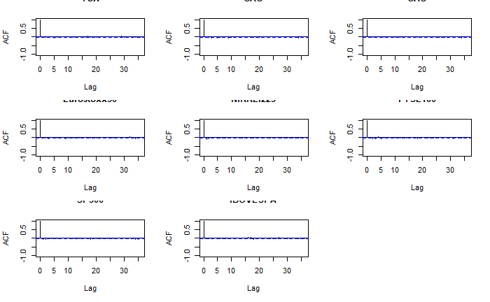

```r
# autocorrelation for each index
# auto_cor = apply(log_daily_return[,-1], 2, acf)

# Convert data frame to time series
data_xts <- xts(log_daily_return, order.by = as.Date(log_daily_return$date),format = '%Y-%m-%d' )
returns_daily_xts <- na.omit(data_xts[,-1])

# Plot autocorrelation for each index
title <- c( "TSX","CAC","CAC","Eurostoxx50", "NIKKEI225","FTSE100","SP500","IBOVESPA")
par(mfrow = c(3, 3))
for (i in 1:8) {
  acf(as.numeric(returns_daily_xts[,i]), plot=T,ylim = c(-1,1),main = title[i])
}
```

```r
# acf(as.numeric(returns_daily_xts[,1]), plot=T,ylim = c(-0.2,0.2),main= "TSX")
# acf(as.numeric(returns_daily_xts[,2]), plot=T,ylim = c(-0.2,0.2),main= "CAC")
# acf(as.numeric(returns_daily_xts[,3]), plot=T,ylim = c(-1,1),main="CAC")
# acf(as.numeric(returns_daily_xts[,4]), plot=T,ylim = c(-0.2,0.2),main= "Eurostoxx50")
# acf(as.numeric(returns_daily_xts[,5]), plot=T,ylim = c(-0.2,0.2),main= "NIKKEI225")
# acf(as.numeric(returns_daily_xts[,6]), plot=T,ylim = c(-0.2,0.2),main= "FTSE100")
# acf(as.numeric(returns_daily_xts[,7]), plot=T,ylim = c(-1,1),main= "SP500")
# acf(as.numeric(returns_daily_xts[,8]), plot=T,ylim = c(-0.2,0.2),main= "IBOVESPA")
```

## Correlation Matrix

Correlations are all positive and most of them are highly correlated except for NIKKEI225. NIKKEI225 is weakly correlated with the rest of the indexes especially SP500 which has correlation of 0.00064 with NIKKEI225. Overall, these indexes tend to move toward the same directions.

```r
corr_matrix = cor(log_daily_return[,-1])
corr_matrix
```

```
                  TSX       CAC       DAX Eurostoxx50    NIKKEI225   FTSE100        SP500
TSX         1.0000000 0.6054480 0.6054209   0.6056300 0.1257192562 0.6268727 0.7396837963
CAC         0.6054480 1.0000000 0.9116861   0.9814592 0.2115118634 0.8709373 0.5466897845
DAX         0.6054209 0.9116861 1.0000000   0.9450664 0.1882519477 0.8151868 0.5929462576
Eurostoxx50 0.6056300 0.9814592 0.9450664   1.0000000 0.2002665797 0.8675177 0.5608888817
NIKKEI225   0.1257193 0.2115119 0.1882519   0.2002666 1.0000000000 0.2270514 0.0006400986
FTSE100     0.6268727 0.8709373 0.8151868   0.8675177 0.2270513698 1.0000000 0.5385025220
SP500       0.7396838 0.5466898 0.5929463   0.5608889 0.0006400986 0.5385025 1.0000000000
IBOVESPA    0.6036287 0.4828383 0.4974479   0.4873130 0.0593528591 0.4995873 0.5930348537
              IBOVESPA
TSX         0.60362871
CAC         0.48283827
DAX         0.49744793
Eurostoxx50 0.48731299
NIKKEI225   0.05935286
FTSE100     0.49958728
SP500       0.59303485
IBOVESPA    1.00000000
```

## Summary statistics

Below provides a table that summarises mean, standard deviation, skewneess and kurtosis for each index.

```r
summary_stat <- rbind(mean, std_dev,ske, kurtosis)
summary_stat
```

```
                   TSX           CAC           DAX   Eurostoxx50     NIKKEI225       FTSE100
mean      0.0001017803 -5.204957e-05  0.0001091897 -8.958102e-05 -4.743869e-05 -5.839154e-05
std_dev   0.0143899267  1.647415e-02  0.0166766397  1.667836e-02  1.554133e-02  1.369582e-02
ske      -0.7160791867  2.123472e-02 -0.0112945368 -6.166816e-03 -3.138791e-01 -1.438230e-01
kurtosis 10.8308901815  8.463801e+00  7.8643416194  7.873810e+00  8.748768e+00  1.007294e+01
                 SP500      IBOVESPA
mean      7.502743e-05  0.0000345715
std_dev   1.242561e-02  0.0248127897
ske      -1.818564e-01 -0.1474296795
kurtosis  1.142322e+01  8.3022617454
```

## Summary

```r
summary(log_daily_return[,-1])
```

```
      TSX                  CAC                  DAX              Eurostoxx50
 Min.   :-0.1270422   Min.   :-1.147e-01   Min.   :-0.0933772   Min.   :-1.019e-01
 1st Qu.:-0.0063287   1st Qu.:-8.234e-03   1st Qu.:-0.0080654   1st Qu.:-8.532e-03
 Median : 0.0008451   Median : 2.865e-04   Median : 0.0005260   Median : 2.244e-04
 Mean   : 0.0001018   Mean   :-5.205e-05   Mean   : 0.0001092   Mean   :-8.958e-05
 3rd Qu.: 0.0071587   3rd Qu.: 8.650e-03   3rd Qu.: 0.0085780   3rd Qu.: 8.600e-03
 Max.   : 0.0866889   Max.   : 1.248e-01   Max.   : 0.1270912   Max.   : 1.230e-01
   NIKKEI225             FTSE100               SP500               IBOVESPA
 Min.   :-1.371e-01   Min.   :-9.731e-02   Min.   :-9.470e-02   Min.   :-1.808e-01
 1st Qu.:-8.149e-03   1st Qu.:-6.431e-03   1st Qu.:-5.126e-03   1st Qu.:-1.250e-02
 Median : 3.386e-04   Median : 2.138e-04   Median : 1.818e-04   Median : 1.861e-04
 Mean   :-4.744e-05   Mean   :-5.839e-05   Mean   : 7.503e-05   Mean   : 3.457e-05
 3rd Qu.: 8.305e-03   3rd Qu.: 6.907e-03   3rd Qu.: 5.687e-03   3rd Qu.: 1.338e-02
 Max.   : 1.318e-01   Max.   : 1.110e-01   Max.   : 1.096e-01   Max.   : 2.134e-01
```

## Normality: Evaluating whether it is reasonable to approximate the return process by i.i.d. Gaussian distribution.

```r
# hgA <- hist(log_daily_return[,2], plot = FALSE) # Save first histogram data
# hgB <- hist(log_daily_return[,3], plot = FALSE) # Save 2nd histogram data
# plot(hgA, col = "red50") # Plot 1st histogram using a transparent color
# plot(hgB, col = "blue50", add = TRUE) # Add 2nd histogram using different color
# Log return plot
plot(density(log_daily_return[,2]),xlim= c(-0.2,0.2),ylim = c(0,100))
lines(density(log_daily_return[,3]))
```

```r
lines(density(log_daily_return[,4]))
lines(density(log_daily_return[,5]))
```

```r
lines(density(log_daily_return[,6]))
lines(density(log_daily_return[,7]))
```

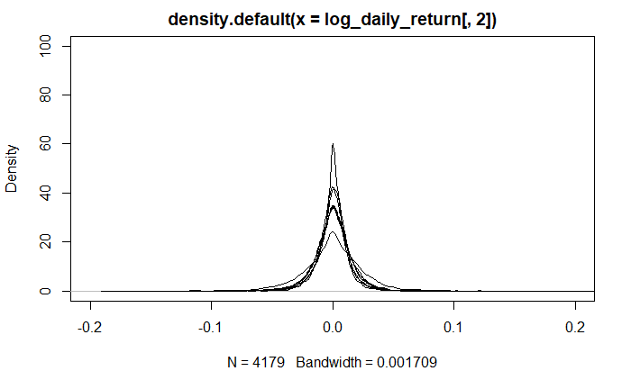

```r
lines(density(log_daily_return[,8]))
lines(density(log_daily_return[,9]))
```

```r
# Normal return plot
plot(density(daily_return[,2]),xlim= c(-0.2,0.2),ylim = c(0,100),col="red")
lines(density(daily_return[,2]),col= "red")
```

```r
lines(density(daily_return[,3]),col= "red")
lines(density(daily_return[,4]),col= "red")
```

```r
lines(density(daily_return[,5]),col= "red")
lines(density(daily_return[,6]),col= "red")
```

```r
lines(density(daily_return[,7]),col= "red")
lines(density(daily_return[,8]),col= "red")
```

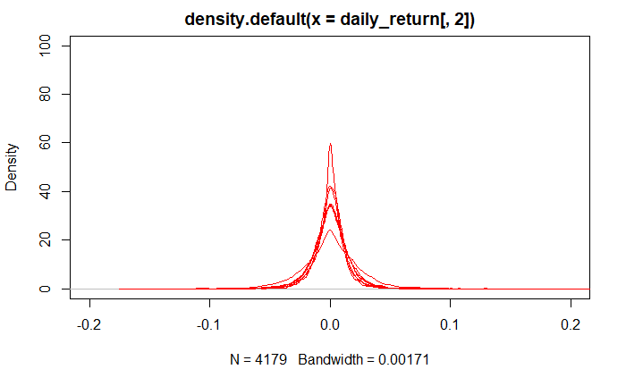

```r
lines(density(daily_return[,9]),col= "red")
```

```r
# shapiro wilk test
for (i in 2:9){
  print(shapiro.test(log_daily_return[,i]))
}
```

```
    Shapiro-Wilk normality test

data:  log_daily_return[, i]
W = 0.9113, p-value < 2.2e-16


    Shapiro-Wilk normality test

data:  log_daily_return[, i]
W = 0.94319, p-value < 2.2e-16


    Shapiro-Wilk normality test

data:  log_daily_return[, i]
W = 0.94853, p-value < 2.2e-16


    Shapiro-Wilk normality test

data:  log_daily_return[, i]
W = 0.94624, p-value < 2.2e-16


    Shapiro-Wilk normality test

data:  log_daily_return[, i]
W = 0.95254, p-value < 2.2e-16


    Shapiro-Wilk normality test

data:  log_daily_return[, i]
W = 0.92929, p-value < 2.2e-16


    Shapiro-Wilk normality test

data:  log_daily_return[, i]
W = 0.90964, p-value < 2.2e-16


    Shapiro-Wilk normality test

data:  log_daily_return[, i]
W = 0.95354, p-value < 2.2e-16
```

# Mean Variance Analysis

```r
#install.packages("fPortfolio",repos = "http://cran.us.r-project.org")
#install.packages("fAssets",repos = "http://cran.us.r-project.org")
library(fAssets)
library(ggplot2)
library(fPortfolio)
library(quadprog) # for portfolio
```

## Situation 1: short selling allowed

In this part, I assume risk free rate is 0 and there are 252 trading days each year.

```r
nor_daily_return<- daily_return[-c(1)]
# annualised covariance matrix
nor_cov_matrix <- 252*cov(na.omit(nor_daily_return))
# annualised mean
nor_mean <- ((1+colMeans(nor_daily_return,na.rm = TRUE))^252)-1
```

Tangency portfolio is then calculated in two ways. (1) Manual calculation

```r
knitr::include_graphics("tangencyportfolioformula.png")
```

[output not shown]

```r
# Find the tangency portfolio
# using matrix to calculate portfolio weights
Sigma <- nor_cov_matrix
R <- nor_mean
w <- solve(Sigma) %*% R
w <- w/sum(w)
w
```

```
                   [,1]
TSX           0.9587117
CAC           7.5191451
DAX           8.1501355
Eurostoxx50 -14.6189464
NIKKEI225     0.2028951
FTSE100      -1.0974022
SP500        -0.4806745
IBOVESPA      0.3661357
```

2. R package

```r
# use solve.QP to get the weights
# solve quadratic problem
Dmat <- nor_cov_matrix
dvec <- matrix(nor_mean,nrow = 8,ncol = 1)
Amat <- t(matrix(1,1,8))
bvec <- c(1)
optimal_weights1 <-solve.QP(Dmat,dvec,Amat,bvec,meq = 1)
optimal_weights1$solution
```

```
[1]   0.9111773   7.1437011   7.7408865 -13.8975268   0.2091928  -1.0235026  -0.4276055   0.3436772
```

As we can see, these two ways give us similar results of the tangency portfolio. Values of some assets are extream. For example, Eurostoxx50 has almost 1400% short position. Then we should consider to add no short selling constraint.

## Situation 2: short selling disallowed

```r
# minimum variance portfolio
Amat_2 <- cbind(Amat,diag(8))
bvec_2 <- c(1,rep(0,8))

optimal_weights2 <- solve.QP(Dmat,dvec,Amat=Amat_2 ,bvec=bvec_2,meq = 1)
optimal_weights2$solution
```

```
[1]  2.298115e-01 -5.449416e-18  4.598038e-01  2.347856e-16  1.966925e-02 -4.320922e-16
[7]  4.676425e-17  2.907154e-01
```

As we can see, the constrained tangency portfolio is more realistic with reasonable weights of some assets comparing to the unconstrained tangency portfolio.

```r
# Tangency portfolio
time_series_return=as.timeSeries(daily_return,na.rm = TRUE)
tangencyPortfolio(as.timeSeries(na.omit(time_series_return)),constraints = "LongOnly")
```

```
Title:
 MV Tangency Portfolio
 Estimator:         covEstimator
 Solver:            solveRquadprog
 Optimize:          minRisk
 Constraints:       LongOnly

Portfolio Weights:
        TSX         CAC         DAX Eurostoxx50   NIKKEI225     FTSE100       SP500    IBOVESPA
     0.2929      0.0000      0.3861      0.0000      0.1118      0.0000      0.0000      0.2092

Covariance Risk Budgets:
        TSX         CAC         DAX Eurostoxx50   NIKKEI225     FTSE100       SP500    IBOVESPA
     0.2548      0.0000      0.4068      0.0000      0.0347      0.0000      0.0000      0.3037

Target Returns and Risks:
  mean    Cov   CVaR    VaR
0.0002 0.0137 0.0326 0.0216

Description:
 Sat Jan 01 20:29:27 2022 by user: Yuting Huang
```

### Efficient frontier

```r
# plot Efficient frontier
frontier2 <- minvariancePortfolio(na.omit(time_series_return))
frontier_plot <- frontierPlot(portfolioFrontier(data = na.omit(time_series_return)))
grid()
```

```r
minvariancePoints(frontier2,col="red",pch=20) # highlight the minimum variance point
tangencyPoints(frontier2,col="green", pch=20) # highlight the tangency portfolio point
```

[figure not shown]

```r
cmlPoints(frontier2,col="blue",pch=4) # highlight the capital market portfolio point

tangencyLines(frontier2,col="red")
```

By adding the non-shorting-selling constraint, we get a more realistic efficient frontier with the tangency portfolio.

# Mean Variance Analysis with 5-year Rolling Window

```r
## Clean and sort data
library(quadprog) # for portfolio
## Compute list of means and list of covariance matrix based on 5-year rolling window
begindates = c("2000-01-01","2001-01-01","2002-01-01","2003-01-01","2004-01-01","2005-01-01","2006-01-01","2007-01-01","2008-01-01","2009-01-01","2010-01-01","2011-01-01")
enddates = c("2004-12-31","2005-12-31","2006-12-31","2007-12-31","2008-12-31","2009-12-31","2010-12-31","2011-12-31","2012-12-31","2013-12-31","2014-12-31","2015-12-31")
listofreturns = list()
for (i in 1:length(begindates))
  listofreturns[[i]] = daily_return %>% filter(daily_return$date >= begindates[i] & daily_return$date <= enddates[i])

listofmeans = list()
for (i in 1:length(listofreturns))
  {
  listofmeans[[i]] = colMeans(as.matrix(listofreturns[[i]][-c(1)]), na.rm = T)
}

listofcov = list()
for (i in 1:length(listofreturns))
  {
  listofcov[[i]] = cov(na.omit(as.matrix(listofreturns[[i]][-c(1)])))
}

## Allow short sell
w_roll <- matrix(ncol = 12, nrow = 8) # Create an empty matrix
for (i in 1:12){
  w1 <- solve(listofcov[[i]])%*%listofmeans[[i]]
  w_roll[,i] <- w1
}
colnames(w_roll) <- c("Period 1","Period 2","Period 3","Period 4","Period 5","Period 6","Period 7","Period 8","Period 9","Period 10","Period 11","Period 12")
rownames(w_roll) <- c("TSX","CAC","DAX","Eurostoxx50","NIKKI225","FTSE100","SP500","IBOVESPA")
w_roll
```

```
              Period 1   Period 2    Period 3    Period 4    Period 5      Period 6     Period 7
TSX          4.1840087  6.3974365   7.2659628   8.4241219   2.7342048   2.394710617   1.62840050
CAC          3.2137957  5.0830877  14.6841832   8.9908462  15.6176545  10.648165542  10.18279567
DAX          0.6202310  2.6962803   6.1199835  20.0588513  18.8296079  17.064565442  18.74386691
Eurostoxx50 -3.4419838 -8.7137168 -21.0172040 -25.0190095 -29.4162234 -25.210619712 -27.28264572
NIKKI225    -1.2671768  0.2690770   0.9411132   0.7322032  -0.5415366  -0.005925061   0.01905139
FTSE100     -1.1568947  0.5091171   1.8495296  -2.1633700  -5.8136971  -3.549116418  -1.76735580
SP500       -2.9786167 -4.1536484  -4.0829787  -8.1005873  -6.0492109  -6.077927089  -4.47375503
IBOVESPA     0.7040895  1.0432900   1.4802570   3.3821111   2.1720535   3.133905022   2.62601296
              Period 8    Period 9  Period 10   Period 11  Period 12
TSX           1.413388   0.3529955  -2.324409  -6.8706565 -12.310494
CAC           4.104049   9.2737123   1.429624  -0.7927085   8.824187
DAX          13.035034  12.3584316  16.710219  17.0132637  12.475383
Eurostoxx50 -17.381261 -21.3759792 -20.322297 -17.4776880 -19.949928
NIKKI225     -0.163443   0.1703271   1.951409   1.6201618   1.917759
FTSE100      -0.545854  -0.1778036   4.227455   1.7778940   0.422225
SP500        -3.137504  -0.2906377   8.214361  17.7830449  18.775873
IBOVESPA      1.950721   0.3819400  -1.266655  -3.5335960  -3.558255
```

## Find the minimum variance portfolio (Short sell allowed)

```r
mv_roll <- matrix(ncol = 8, nrow = 12) # Create an empty matrix
for (i in 1:12){
  Dmat2 <- listofcov[[i]]
  dvec2 <- matrix(listofmeans[[i]],nrow = 8,ncol = 1)
  Amat2 <- t(matrix(1,1,8))
  bvec2 <- c(1)
  optimal_weights2 <-solve.QP(Dmat2,dvec2,Amat2,bvec2,meq = 1)
  mv_roll[i,] <- optimal_weights2$solution
}
rownames(mv_roll) <- c("2004-01-01","2005-01-01","2006-01-01","2007-01-01","2008-01-01","2009-01-01","2010-01-01","2011-01-01","2012-01-01","2013-01-01","2014-01-01","2015-01-01")
colnames(mv_roll) <- c("TSX","CAC","DAX","Eurostoxx50","NIKKI225","FTSE100","SP500","IBOVESPA")
mv_roll
```

```
                   TSX       CAC        DAX Eurostoxx50    NIKKI225     FTSE100        SP500
2004-01-01   4.4488166  3.459438  0.5018619   -3.803494 -1.02411852 -0.66482609  -2.61039837
2005-01-01   5.6868965  4.558579  2.9584256   -7.867628 -0.09697338 -0.47024509  -4.84745381
2006-01-01   5.6416082 13.616658  6.8955886  -18.604377 -0.16334633 -1.22798896  -6.89795928
2007-01-01   7.7599313  9.213608 21.0751974  -25.260479 -0.43706372 -3.87823071 -11.53355214
2008-01-01   2.4867823 15.031633 18.6846877  -28.922962  0.66174838 -5.03135466  -3.53658731
2009-01-01   2.1239531 10.741604 17.2292726  -25.802660  0.98809597 -2.84631171  -4.16748648
2010-01-01   1.5000756 10.136891 18.9843258  -27.702938  0.52576004 -1.35716754  -3.49226706
2011-01-01   1.2242739  3.701335 13.1035551  -17.497430  0.54523063  0.08918588  -1.85246372
2012-01-01   0.3134525  9.207376 12.3584639  -21.393429  0.29654158 -0.06009808  -0.06120247
2013-01-01  -1.5535800  2.908276 17.0782895  -19.401934 -0.67738301  0.66905048   2.47758872
2014-01-01  -6.7900370  2.768637 17.4983364  -18.207010 -0.91272075 -2.22036861  11.86629534
2015-01-01 -12.4001222 10.374604 13.2202134  -20.594530  0.24702599 -1.84215651  15.19525707
             IBOVESPA
2004-01-01  0.6927199
2005-01-01  1.0783989
2006-01-01  1.7398174
2007-01-01  4.0605889
2008-01-01  1.6260525
2009-01-01  2.7335324
2010-01-01  2.4053203
2011-01-01  1.6863130
2012-01-01  0.3388962
2013-01-01 -0.5003073
2014-01-01 -3.0031325
2015-01-01 -3.2002923
```

## Find the minimum variance portfolio (Short sell prohibited)

```r
mv_roll_noshort <- matrix(ncol = 8, nrow = 12) # Create an empty matrix
for (i in 1:12){
  Dmat2 <- listofcov[[i]]
  dvec2 <- matrix(listofmeans[[i]],nrow = 8,ncol = 1)
  A_roll <- cbind(Amat2,diag(8))
  b_roll <- c(1,rep(0,8))
  optimal_weights_roll <- solve.QP(Dmat2,dvec2,Amat=A_roll ,bvec=b_roll,meq = 1)
  mv_roll_noshort[i,] <- optimal_weights_roll$solution
}
rownames(mv_roll_noshort) <- c("2004-01-01","2005-01-01","2006-01-01","2007-01-01","2008-01-01","2009-01-01","2010-01-01","2011-01-01","2012-01-01","2013-01-01","2014-01-01","2015-01-01")
colnames(mv_roll_noshort) <- c("TSX","CAC","DAX","Eurostoxx50","NIKKI225","FTSE100","SP500","IBOVESPA")
mv_roll_noshort
```

```
                     TSX           CAC           DAX   Eurostoxx50      NIKKI225       FTSE100
2004-01-01  7.345322e-01  0.000000e+00  8.739756e-18  9.292506e-17  0.000000e+00  4.175243e-18
2005-01-01  3.322113e-01  4.021482e-16  0.000000e+00  9.930987e-17  0.000000e+00  9.390240e-17
2006-01-01  0.000000e+00 -2.782394e-16  0.000000e+00  1.023092e-15  1.006762e-18 -1.064751e-15
2007-01-01  0.000000e+00 -8.530112e-16  0.000000e+00 -3.552714e-15 -2.220446e-16  1.511744e-15
2008-01-01  3.145934e-17 -3.127955e-16  0.000000e+00 -4.267272e-16  0.000000e+00 -1.007101e-16
2009-01-01  1.386231e-16  3.527187e-16 -6.282960e-16 -4.501200e-16  5.551115e-17 -7.940919e-17
2010-01-01  1.401850e-16 -3.692480e-16 -1.889899e-16  3.452144e-15  0.000000e+00  2.298619e-16
2011-01-01 -1.194884e-16 -2.048884e-16 -1.092725e-17  1.149127e-16  6.811785e-02  4.200896e-17
2012-01-01  6.479541e-17  2.710073e-16  1.353495e-18  3.540906e-15  3.856086e-01  2.581787e-17
2013-01-01  1.886016e-16  1.217723e-15  2.420195e-01  0.000000e+00  0.000000e+00 -2.470229e-16
2014-01-01 -1.161364e-17  2.143906e-15 -3.036325e-17  9.089410e-17  0.000000e+00  2.340144e-15
2015-01-01  2.494700e-15  1.852011e-16 -6.592304e-17  0.000000e+00  0.000000e+00  2.892569e-16
                   SP500      IBOVESPA
2004-01-01 -1.251173e-16  2.654678e-01
2005-01-01 -1.670777e-16  6.677887e-01
2006-01-01  1.409136e-16  1.000000e+00
2007-01-01  4.808872e-16  1.000000e+00
2008-01-01  0.000000e+00  1.000000e+00
2009-01-01  9.529079e-16  1.000000e+00
2010-01-01 -3.213580e-16  1.000000e+00
2011-01-01 -7.396681e-17  9.318821e-01
2012-01-01  3.994546e-01  2.149368e-01
2013-01-01  7.579805e-01  3.989790e-18
2014-01-01  1.000000e+00 -7.703584e-16
2015-01-01  1.000000e+00  3.682661e-16
```

## Examine if this portfolio is significantly time-varying

```r
### M-V (no short selling)
# Organise data
mv_roll_noshort_df <- as.data.frame(mv_roll_noshort)
mydf <- cbind(rownames(mv_roll_noshort_df), mv_roll_noshort_df)
rownames(mydf) <- NULL
colnames(mydf) <- c("Year","TSX","CAC","DAX","Eurostoxx50","NIKKI225","FTSE100","SP500","IBOVESPA")
# convert to timeseries
mv_roll_noshort_xts <- xts(mydf, order.by = as.Date(mydf$Year),format = '%Y-%m-%d' )
zoo.basket <- as.zoo(mv_roll_noshort_xts)
tsRainbow <- rainbow(ncol(zoo.basket))
plot(x = zoo.basket, ylab = "Weight", main = "Weight for non-short selling portfolio",col = tsRainbow, screens = 1,ylim = c(-3,3))
```

```
NAs introduced by coercion
```

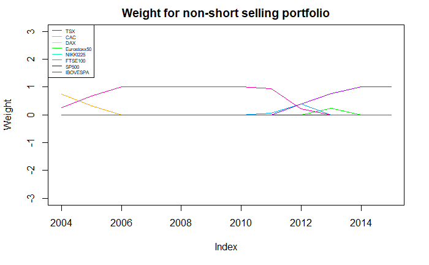

```r
legend(x = 'topleft', legend = c("TSX","CAC","DAX","Eurostoxx50","NIKKI225","FTSE100","SP500","IBOVESPA"),
       lty = 1,col = tsRainbow,cex = 0.5)
```

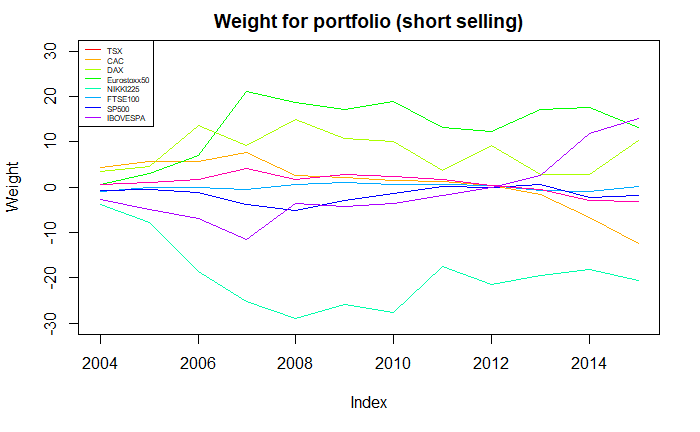

```r
### M-V (short selling allowed)
# Organise data
mv_roll_df <- as.data.frame(mv_roll)
mydf2 <- cbind(rownames(mv_roll_df), mv_roll_df)
rownames(mydf2) <- NULL
colnames(mydf2) <- c("Year","TSX","CAC","DAX","Eurostoxx50","NIKKI225","FTSE100","SP500","IBOVESPA")
# convert to timeseries
mv_roll_xts <- xts(mydf2, order.by = as.Date(mydf2$Year),format = '%Y-%m-%d' )
zoo.basket2 <- as.zoo(mv_roll_xts)
tsRainbow2 <- rainbow(ncol(zoo.basket2))
plot(x = zoo.basket2, ylab = "Weight", main = "Weight for portfolio (short selling)",col = tsRainbow, screens = 1,ylim = c(-30,30))
legend(x = 'topleft', legend = c("TSX","CAC","DAX","Eurostoxx50","NIKKI225","FTSE100","SP500","IBOVESPA"),
       lty = 1,col = tsRainbow2,cex = 0.5)
```

## Compare Market-based weights and Mean-Variance weights

Weights calculated by market capital and mean-variance approaches varies in a large degree. By allowing short selling, composition weight of portfolio deviates from strategies that prohibit short selling even more.

```r
Mktcap_data <- read_excel("PS1_data.xls",sheet ="market_cap", skip = 1)
Mktcap_weight <- Mktcap_data[5,]

# Compare market-cap weights and mean-variance weights
MV_weight_short <- optimal_weights1$solution
MV_weight_noshort <- optimal_weights2$solution
comparison <- rbind(Mktcap_weight,MV_weight_short,MV_weight_noshort)
comparison <- as.data.frame(comparison)
rownames(comparison) <- c("Market-Cap Weight","Mean-Variance Weight (with short sale)","Mean-Variance Weight (without short sale)" )
comparison
```

[output not shown]

```r
NA
```